# Project_2

Collin Baird

01 May, 2024

Abstract

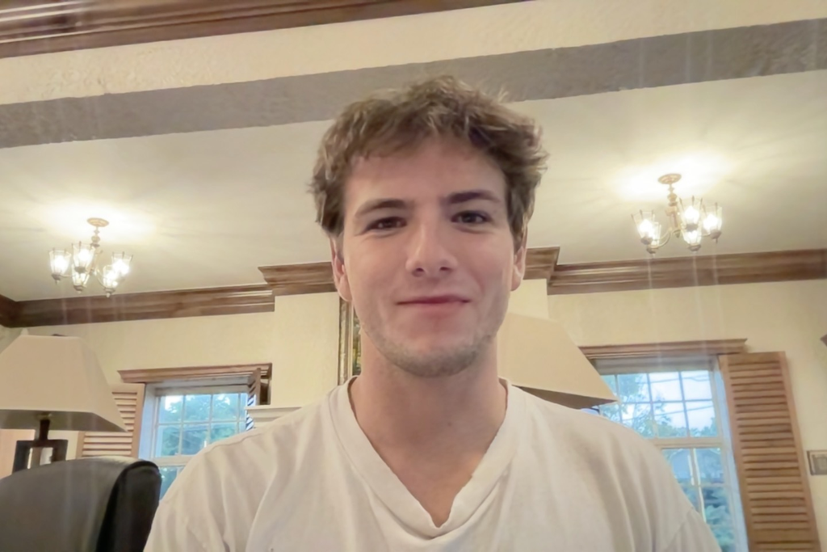

Collin Baird

# 1 Introduction

In this project I will use a simple linear regression model to evaluate if the distance a home is from a fire station in miles, effects the amount of damages in thousands of dollars that a home will incur.

## 1.1 Background of Data

This data was collected by an insurance agency that is wanting to better understand the relation to cost of residential fires to the distance of the home to the nearest fire station in a large suburb. A sample of 15 recent fires was selected in order to obtain the data that I will use.(see Mendenhall 2016)

## 1.3 Plot of Data

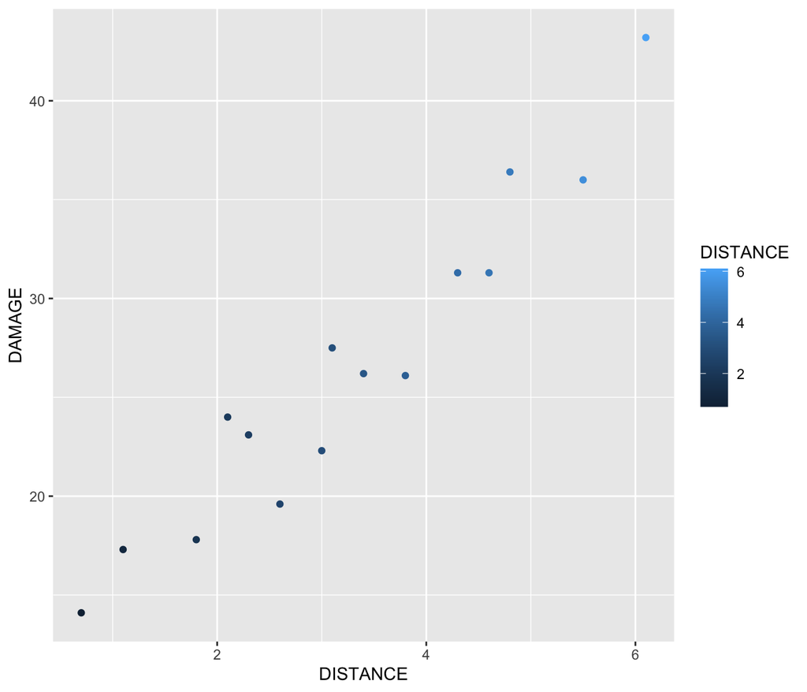

```r
library(ggplot2)

g = ggplot(fire, aes(x = DISTANCE, y = DAMAGE, color = DISTANCE)) + geom_point()
g
```

# 2 Theory behind Analysis

In order to determine whether the distance a home is from the nearest fire station has an affect on the cost of the damages that are done by a fire on the home I will use a simple linear regression. I will be using this model because it will give me the best estimate of if the two variables are related to one another. As I discussed before my dependent variable will be y which is the damage in thousands of dollars caused by a fire to a home, and my independent variable will be x, which is the distance in miles from the home to the nearest fire station. I believe that the further a home is away from a fire station the higher the cost of damages that the fire will cause on the home. The simple linear regression model assumes that the mean value of y for any x of the data collected will create a straight line, and that any point that deviates from that line will be equal to the term $\epsilon$

The equation for a simple linear regression line is:

$y = \beta_0 + \beta_1x + \epsilon$

With the value $\beta_0$ being the intercept of the line and the value of $\beta_1$ being the slop of the line, which is one of the main things that I will be observing. This value is what tells us by home much or how little the value of x affects y.

I will also be assuming and proving that the $E(\epsilon) = 0$ which means that I will have the definition of the $E(y)$ to be:

$E(y) = E(\beta_0 + \beta_1x + \epsilon)$

$=\beta_0 + \beta_1x + E(\epsilon)$

$=\beta_0 + \beta_1x$

This means that we can estimate the mean value of y to be the expected value of y given x because of the simple linear regression equation. However, like mentioned before, I will need to make sure that the conditions of an SLR are met which are:

- The $E(\epsilon) = 0$
- The $V(\epsilon) = \sigma^2$
- $\epsilon$ is distributed normally
- The errors and response values are independent

# 3 Validity with mathematical expressions

## 3.1 Ploting line of best fit

In order to see if the SLR is a good method to use I will create a scatter plot of the values and draw the line of best fit onto the graph.

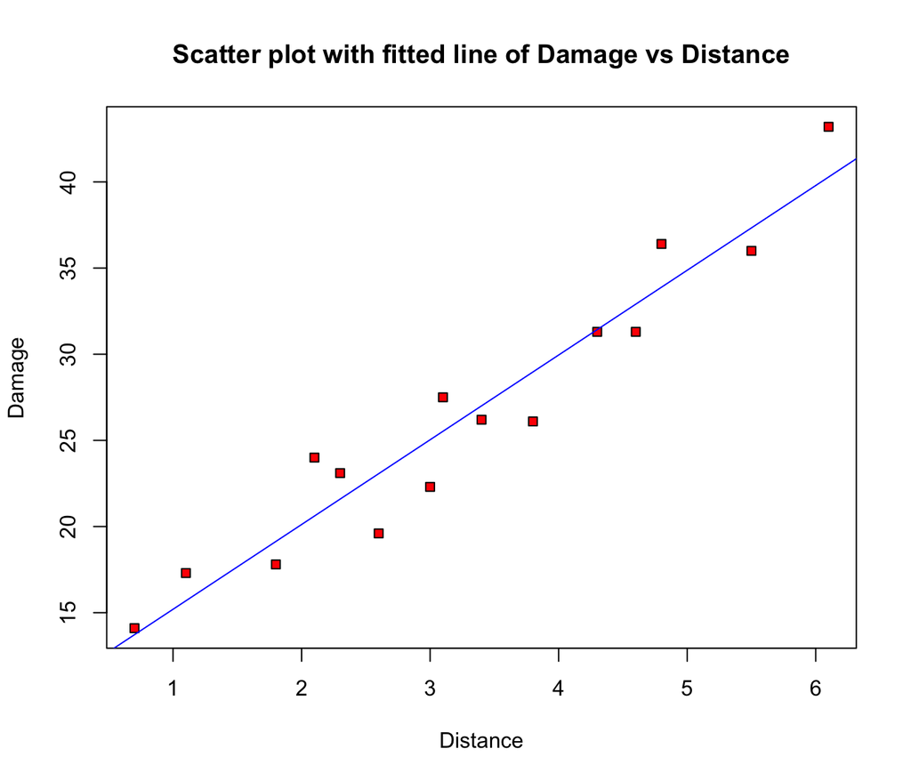

```r
fire_line <- lm(DAMAGE ~ DISTANCE, data = fire)
plot(DAMAGE~DISTANCE, bg = "red", pch = 22, xlab = "Distance", ylab = "Damage", main = "Scatter plot with fitted line of Damage vs Distance", data = fire)
abline(fire_line, col = "blue")
```

Observing this scatter plot, it looks as if a simple linear regression is going to be able to estimate the values with a high level of accuracy.

## 3.2 Plot Risiduals / Prove Varriance of Epsilon

In order to better see how the values of the data differ from the lines I can plot the residuals using line segments. This process will also give us the RSS (Residual Sum of Squares) which I will use further along to prove that we can use SLR.

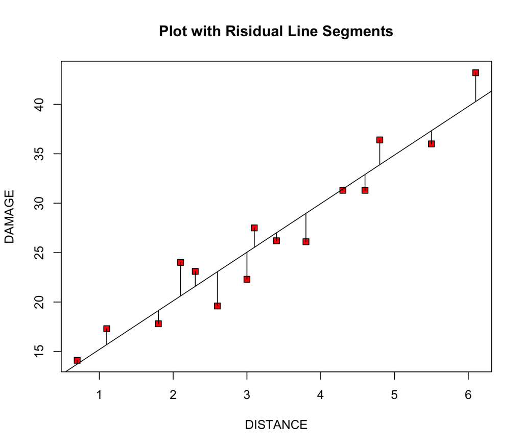

```r
plot(DAMAGE~DISTANCE,bg="red",pch=22,cex=1.2, main="Plot with Risidual Line Segments", data=fire)
abline(fire_line)
yhat=with(fire,predict(fire_line,data.frame(DISTANCE)))#finding value on the line with predect
with(fire,{segments(DISTANCE,DAMAGE,DISTANCE,yhat)})
```

```r
RSS=with(fire,sum((DAMAGE-yhat)^2))
var <- RSS/summary(fire_line)$df[2] #calculating the variance of epsilon
var.s <- summary(fire_line)$sigma^2 #checking the print out for sigma^2
list(variance_epsilon = var, sigma_sq = var.s)
```

```
## $variance_epsilon
## [1] 5.36546
##
## $sigma_sq
## [1] 5.36546
```

## 3.3 Ploting Means

I will next plot the expected deviation from the points to the mean value of damage given the best fitted line. This will give us an idea of what amount of damage is expected given a certain distance away from the nearest fire station. This value would be equal to $\hat y_i - \bar y$. Graphing this is important because the R^2 value which is the value that will show us how well our line fits the data is calculated by $R^2 = \frac{MSS}{TSS}$ where $MSS = \sum_{i = 1}^{n}(\hat y_i - \bar y)^2$ which means the total amount of distance away the line of best fit is from the mean for every point. The value SSE is the total amount of unexplained deviation from the line of best fit. The equation for SEE is $\sum_{i = 1}^{n}(y_i - \bar y)^2$ and TSS = MSS + RSS. This graph will visualize the SSR values.

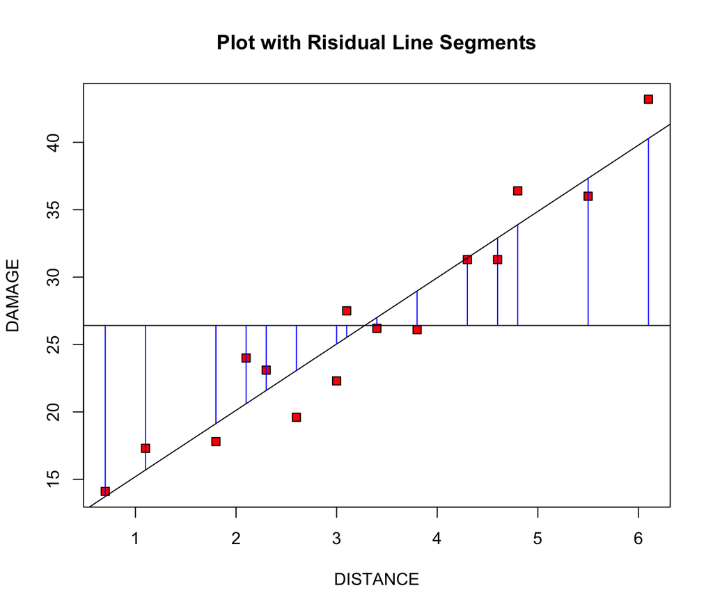

```r
plot(DAMAGE~DISTANCE,bg="red",pch=22,cex=1.2, main="Plot with Risidual Line Segments", data=fire)
abline(fire_line)
with(fire, abline(h=mean(DAMAGE)))
with(fire, segments(DISTANCE,mean(DAMAGE),DISTANCE,yhat,col="blue"))
```

The blue lines on the graph represent the individual values $\hat y_i - \bar y$ for all data points.

## 3.4 Ploting total Deviation

In order to visualize the total deviation from the mean value of damage a point is I will use a graph to show the deviation. This is important because as said before in order to calculate the R^2 value we must find TSS which will be the sum of all of the distances a point is away from the mean of damage.

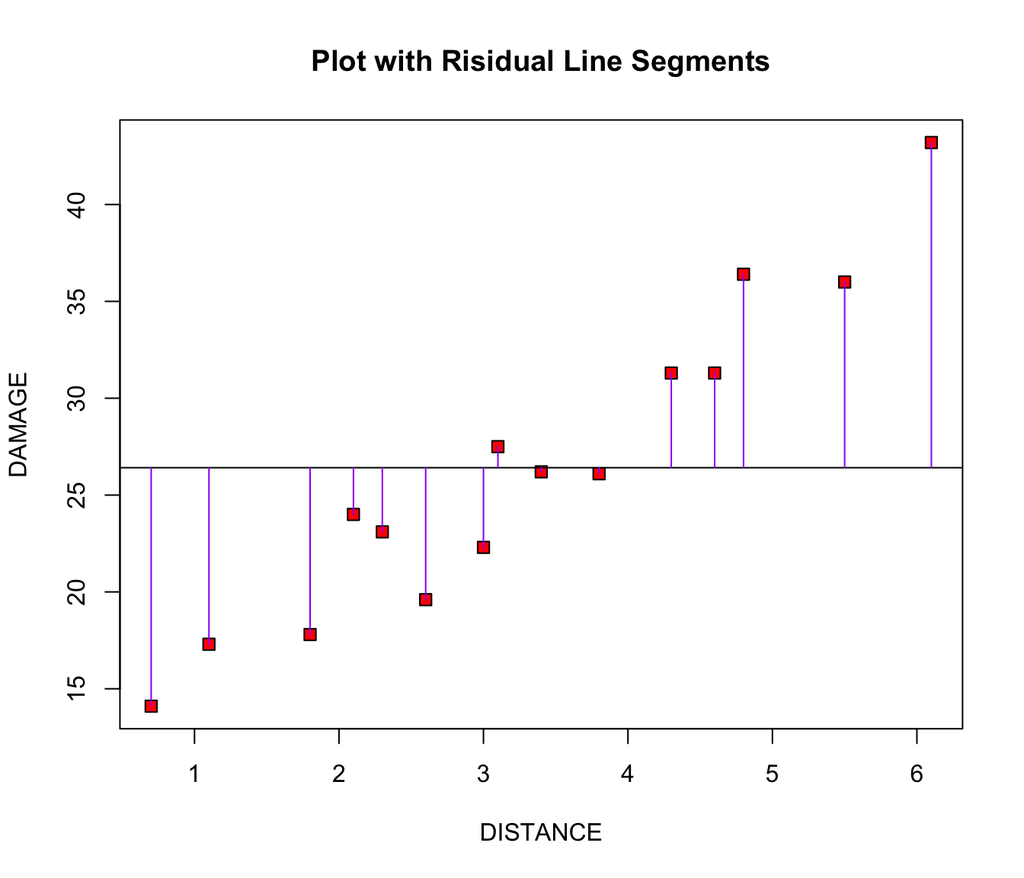

```r
plot(DAMAGE~DISTANCE,bg="red",pch=22,cex=1.2, main="Plot with Risidual Line Segments", data=fire)
with(fire, abline(h=mean(DAMAGE)))
with(fire, segments(DISTANCE,DAMAGE,DISTANCE,mean(DAMAGE),col="purple"))
```

## 3.5 Calculating RSS, MSS, and TSS

### 3.5.1 RSS

```r
RSS=with(fire,sum((DAMAGE-yhat)^2))
RSS
```

```
## [1] 69.75098
```

### 3.5.2 MSS

```r
MSS=with(fire,sum((yhat-mean(DAMAGE))^2))
MSS
```

```
## [1] 841.7664
```

### 3.5.3 TSS

```r
TSS=with(fire,sum((DAMAGE-mean(DAMAGE))^2))
TSS
```

```
## [1] 911.5173
```

## 3.6 R Squared

```r
R_squared = MSS/TSS
R_squared
```

```
## [1] 0.9234782
```

This value as said earlier shows how well the trend line fits the data, and this calculation is proven to be true when we look back at the summary of our linear model and see that the $R^2$ value is .9235

## 3.7 Checking Linear Trend

In order to make sure that the data is taking on a linear pattern we have to use trendscatter. This also allows for us to see if the line of best fit falls within the range it should.

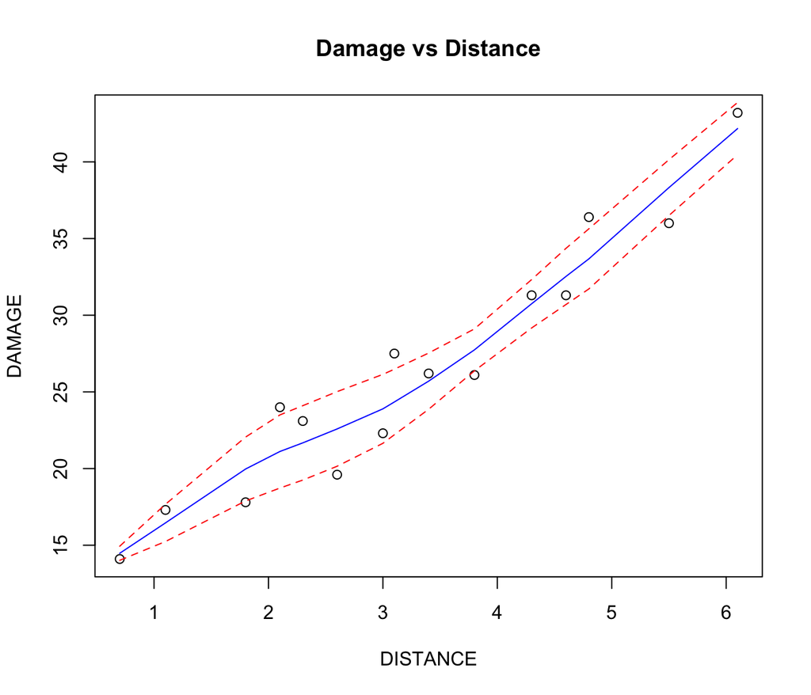

```r
library(s20x)
trendscatter(DAMAGE~DISTANCE, f = 0.5, data = fire, main="Damage vs Distance")
```

Looking at the graph, the data does have a fairly linear pattern, and our line of best fit fall within the acceptable range.

## 3.8 Checking distribution of Errors

Finding the Residuals:

```r
res = residuals(fire_line)
```

Finding the Fitted Values:

```r
fit = fitted(fire_line)
```

In order to see that the residuals are distributed normally, I will make a plot to see that they are distributed normally around the 0 value of the y axis. The values seem to be distributed in a normal way about the y value of zero.

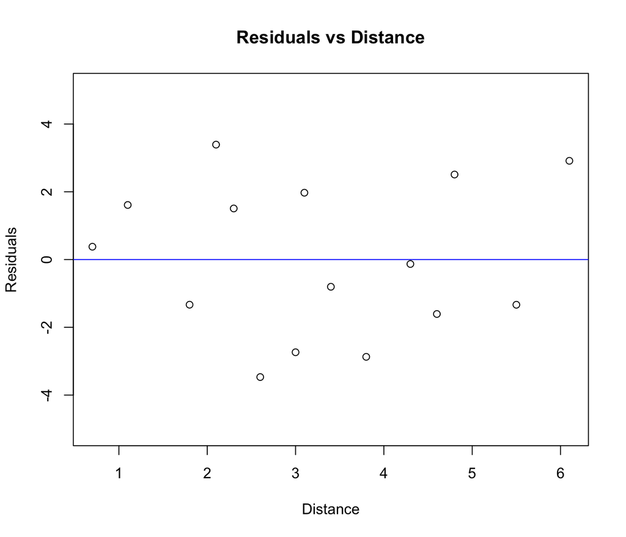

```r
plot(fire$DISTANCE,res, xlab="Distance",ylab="Residuals",ylim=c(-1.5*max(res),1.5*max(res)), main="Residuals vs Distance")
abline(h = 0, col = "blue")
```

## 3.9 Proving Errors are Distributed Normally

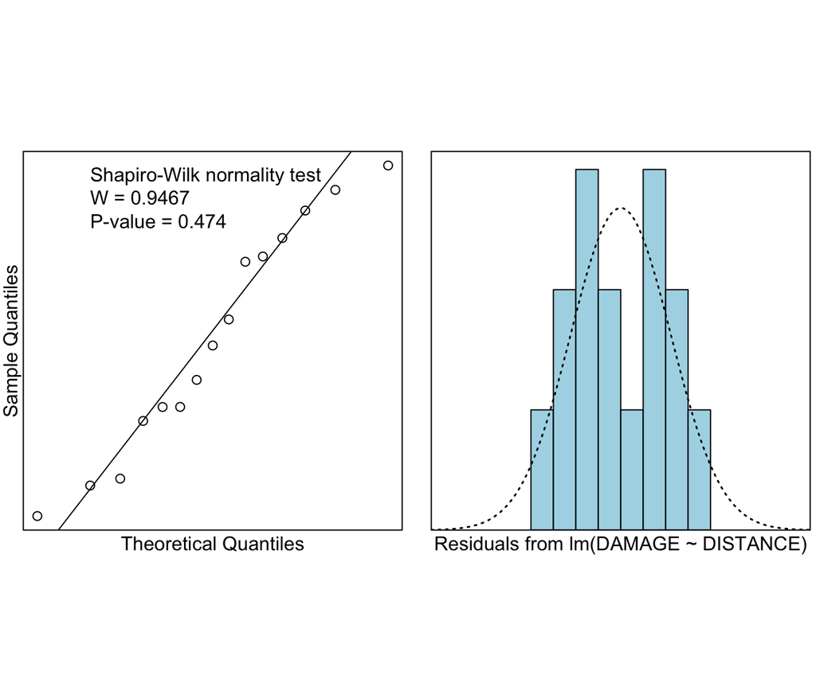

```r
normcheck(fire_line, shapiro.wilk = TRUE)
```

The p-value for the Shapiro-Wilk test is 0.474. The null hypothesis in this case would be that the errors are distributed normally which is denoted by:

$\epsilon \sim N(0,\sigma^2)$

The results of the test indicate the we have to accept the null hypothesis (the p-value 0.474 is greater than the standard of comparison, 0.05), causing me to assume that the data is distributed normally.

## 3.10 Constant Variance

### 3.10.1 Risiduals vs Fitted Trendscatter Plot

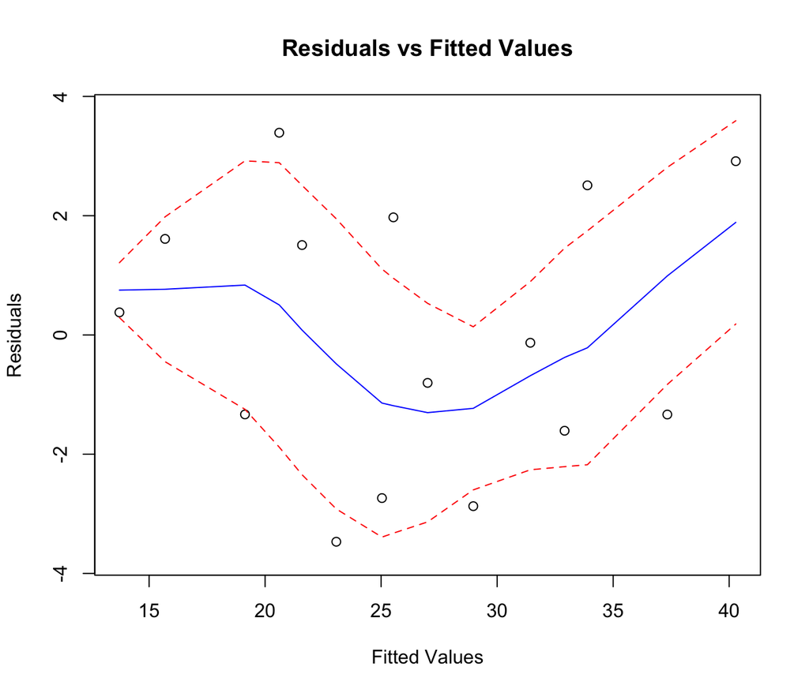

```r
trendscatter(res~fit, f = 0.5, data = fire_line, xlab="Fitted Values",ylab="Residuals",ylim=c(-1.1*max(res),1.1*max(res)), main="Residuals vs Fitted Values")
```

Our sample size is very small, so the values don’t seem to be completely normal, but for a sample size of only 15, the data still shows signs of normality about 0. This further proves that a line of best fit is a good representation for the data.

## 3.11 Exepected value of error is zero

The mean of the residuals must be zero or $E(\epsilon) = 0$ In order to do this I will use R and the definition that $E(\epsilon) = \bar\epsilon$

```r
risid <- fire_line$residuals #extracting residuals from linear regression model
mean <- mean(risid) #finding the mean of the residuals
list(mean_of_risiduals = mean)
```

```
## $mean_of_risiduals
## [1] 0
```

## 3.12 Independence of Data

Since we only have the description that the book gave us of the data collected we must use that to see if it was independently collected. The data is collected from the same large suburb. The data being collected is also based upon individual houses that would not have an affect on one another if they were to catch on fire. (see Mendenhall 2016)

# 4 Analysis of the data

## 4.1 Adding trend to plot

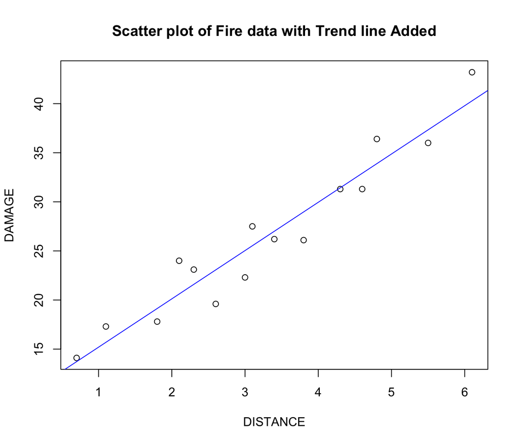

```r
plot(DAMAGE ~ DISTANCE, data = fire, main = "Scatter plot of Fire data with Trend line Added")
abline(fire_line, col = "blue")
```

This graph shows the scatter plot of the Damage vs Distance with the trend line added to it.

## 4.2 Estimating parameters

In order to estimate the parameters I will be using the method of least squares to create a line of best fir for the data. When doing this I will be using the equation from earlier $y = \beta_0 + \beta_1x + \epsilon$ but the estimators will be $\hat y_i = \hat\beta_0 + \hat\beta_1x + \epsilon$

## 4.3 Using Method of Least Squares

```r
fire_line <- lm(DAMAGE ~ DISTANCE, data = fire)
summary(fire_line)
```

```
##
## Call:
## lm(formula = DAMAGE ~ DISTANCE, data = fire)
##
## Residuals:
##     Min      1Q  Median      3Q     Max
## -3.4682 -1.4705 -0.1311  1.7915  3.3915
##
## Coefficients:
##             Estimate Std. Error t value Pr(>|t|)
## (Intercept)  10.2779     1.4203   7.237 6.59e-06 ***
## DISTANCE      4.9193     0.3927  12.525 1.25e-08 ***
## ---
## Signif. codes:  0 '***' 0.001 '**' 0.01 '*' 0.05 '.' 0.1 ' ' 1
##
## Residual standard error: 2.316 on 13 degrees of freedom
## Multiple R-squared:  0.9235, Adjusted R-squared:  0.9176
## F-statistic: 156.9 on 1 and 13 DF,  p-value: 1.248e-08
```

Looking at the print out, the intercept or $\hat \beta_0$ will be equal to 10.2779 and the slope of our line or $\hat \beta_1$ will be equal to 4.9193.

The print out also provides us with the Multiple R-squares which is an indication of how well our line represents the data. The range of the $R^2$ is $0 \le R^2 \le 1$ with the value of 0 being a line that does not fit the data well and a value approaching 1 being a good fit. With the value being .9235, the model seems to have a good representation of the data.

Our p-value is 1.248e-08 which is lower than .05 so we can say that the x value does have an affect on the y value, meaning that the distance a home is away from a fire most likely has an affect on the cost of damages.

## 4.4 Confidence interval for Estimates

```r
ciReg(fire_line, conf.level = .95, print.out = TRUE)
```

```
##             95 % C.I.lower    95 % C.I.upper
## (Intercept)        7.20960          13.34625
## DISTANCE           4.07085           5.76781
```

This shows us that the values for our $\hat \beta_0$ and $\hat \beta_1$ are within the acceptable range.

## 4.5 Interpreting Estimates

Using the estimates and the definition of an SLR I can write the equation as:

$\hat y_i = 10.2779 + 4.9193(x_i)$

The variable $\hat \beta_1$ means that for every mile that a home is away from the nearest fire station, the cost of damages will be 4.9193 thousand dollars more.

## 4.6 Cooks model

In order to make sure that there arent any outliers in the data that are having to much affect on the model, we can use a Cooks distance plot. This is helpfulll because it helps to avoid bias and make a better fitting model for the data. The model takes each point and uses it to estimate its affect on the least sqaures regression. If the cooks distance of a point is too large, it is wise to remove it from the data and make another model in order to get a representation of the data.

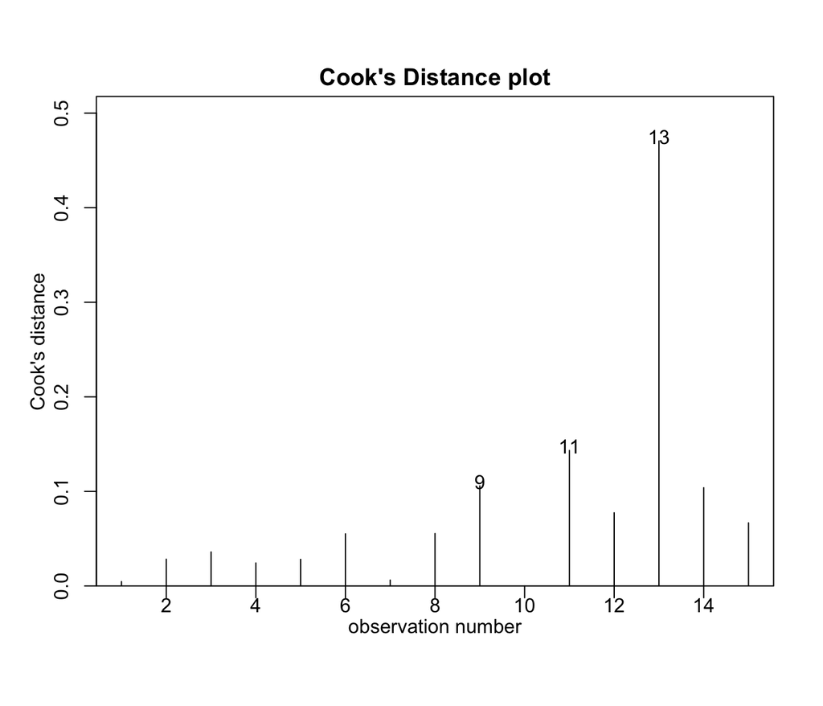

```r
cooks20x(fire_line)
```

Looking at the cooks distance plot, we see that entry 13 has a large affect on the model compared to the other points. In order to see how this point is affecting the model I will remove it and make another model and compare the values of the two.

## 4.7 New Model

```r
fire_line2=lm(DAMAGE ~ DISTANCE, data=fire[-13,])

summary(fire_line2)
```

```
##
## Call:
## lm(formula = DAMAGE ~ DISTANCE, data = fire[-13, ])
##
## Residuals:
##     Min      1Q  Median      3Q     Max
## -3.4205 -1.3871 -0.2625  1.3800  3.2945
##
## Coefficients:
##             Estimate Std. Error t value Pr(>|t|)
## (Intercept)  11.1019     1.4417    7.70 5.55e-06 ***
## DISTANCE      4.5841     0.4279   10.71 1.69e-07 ***
## ---
## Signif. codes:  0 '***' 0.001 '**' 0.01 '*' 0.05 '.' 0.1 ' ' 1
##
## Residual standard error: 2.193 on 12 degrees of freedom
## Multiple R-squared:  0.9053, Adjusted R-squared:  0.8975
## F-statistic: 114.8 on 1 and 12 DF,  p-value: 1.692e-07
```

## 4.8 Old Model

```r
summary(fire_line)
```

```
##
## Call:
## lm(formula = DAMAGE ~ DISTANCE, data = fire)
##
## Residuals:
##     Min      1Q  Median      3Q     Max
## -3.4682 -1.4705 -0.1311  1.7915  3.3915
##
## Coefficients:
##             Estimate Std. Error t value Pr(>|t|)
## (Intercept)  10.2779     1.4203   7.237 6.59e-06 ***
## DISTANCE      4.9193     0.3927  12.525 1.25e-08 ***
## ---
## Signif. codes:  0 '***' 0.001 '**' 0.01 '*' 0.05 '.' 0.1 ' ' 1
##
## Residual standard error: 2.316 on 13 degrees of freedom
## Multiple R-squared:  0.9235, Adjusted R-squared:  0.9176
## F-statistic: 156.9 on 1 and 13 DF,  p-value: 1.248e-08
```

Looking at the out-prints, I can see that the R squared value for the new model is .9053 which is further away from 1 than the value of the old model, which is .9235. This leads me to believe that the second model is not as good of a representation of the data as the first.

# 5 Conclusion

It is important for insurance companies to understand the possible costs of damages that could happen to homes when selling insurance plans. Gathering data and performing tests such as these are very crucial to being able to justify prices and correctly price insurance plans for homes given their locations. I don’t know if it is completely fair to base a home insurance policy on the distance that they are from a fire station, because a home owner shouldn’t be held at fault for actions that are out of their control such as the location of a fire station. Using data in this way could help cities better plan on the location of fire stations in order to reduce total costs of fire damage.

## 5.1 Research Question

My research question was whether the distance a home is from a fire station has an affect on the cost of the damages the home suffered because of the fire. After using a simple linear regression model, and proving that the conditions were met to do so, I came to the conclusion of my question. Looking at the model and the R squared value, I can accept that the model represents the data well, and that the model shows that their is a connection in the distance a home is from a fire-station and the cost of damages caused by a fire. Looking at the model, I can assume that the further a home is from a fire-station, the higher the cost of the damages done by the fire will be. Using the SLR and the high level of accuracy that the model shows, I can say that the data follows a linear trend and this allows for the prediction of cost of damages a home will suffer based on the distance from the nearest fire-station.

## 5.2 Suggestions

This model could be greatly improved by gathering a larger sample size. The sample given was only 15 homes which is repetitively small but if the sample size were larger, a more accurate model would be able to be constructed. There could also be the issue with the overall cost of the home being lower or higher before the fire. This could be avoided by gathering data from similarly priced houses. I feel like a better measurement for this would be response time instead of distance, because response time would be able to show if their were irregularities in traffic or if the crew was running late which would affect how long the fire would burn, overall increasing the cost.

# References

Mendenhall, William M. 2016. *Statistics for Engineering and the Sciences / William m. Mendenhall, Terry l. Sincich.* Sixth edition..